# Lab 2: Why Start With Indicators?

Matt Harris & Michael Fichman

2023-09-08

## Why Start With Indicators?

from Steif (2021), [Section 1.1](https://urbanspatial.github.io/PublicPolicyAnalytics/TOD.html#why-start-with-indicators): This is an indicator - a stylized fact that gives simple insight into a complicated phenomena. Mastering indicators is critical for conveying nuanced context to non-technical audiences. Here are four suggestions on what makes a good indicator:

- A *relatable* indicator is typically motivated by a pressing policy concern. “How is it possible that passenger rail in New York City has such widespread delays, service suspensions, and rider discontent?” A great indicator solicits interest from an audience.
- A *simple* indicator may be used as an exploratory tool in place of more complex statistics. Simplicity helps the audience understand the indicator’s significance and keeps them engaged in the analysis.
- A *relative* indicator draws a contrast. “How can New York City passenger rail, with the most trips, still loose more money than each of the next ten largest cities?” Contextualizing an indicator with a relevant comparison makes for greater impact.
- A *good* indicator typically generates more questions than answers. Thus, a good indicator fits into a broader narrative which helps motivate a more robust research agenda and ultimately, more applied analytics.

In this lab we will walk through:

1. Use {tidycensus} to gather ACS data for two different years
2. Visualize data and maps with {ggplot2}
3. Use the {sf} package for geospatial operations such as **union**, **intersection** and **buffer**
4. Use maps and tables to analyze change over time *given* the products of the geospatial operations

### Load packages and functions

```r
# Load Libraries

library(tidyverse)
library(tidycensus)
library(sf)
library(kableExtra)

options(scipen=999)
options(tigris_class = "sf")

source("https://raw.githubusercontent.com/urbanSpatial/Public-Policy-Analytics-Landing/master/functions.r")

palette5 <- c("#f0f9e8","#bae4bc","#7bccc4","#43a2ca","#0868ac")
```

```r
census_api_key("YOUR KEY GOES HERE", overwrite = TRUE)
```

### Use `get_acs()` to get 2016 ACS data

Notice this returns “long” data - let’s examine it

```r
tracts16 <-
  get_acs(geography = "tract",
          variables = c("B25026_001E","B02001_002E",
                        "B15001_050E","B15001_009E",
                        "B19013_001E", "B25058_001E",
                        "B06012_002E"),
          year=2016, state=42,
          county=101, geometry=TRUE) %>%
  st_transform('ESRI:102728')
```

#### Wide data vs long data (and `spread`vs `gather`)

Take a moment to think about the *shape* of data. The gif below is a visualization of **wide** vs. **long** data. The gif shows the same data transformed into two different shapes. You will do this often in when working with data. **Wide** data is a more common representation and is good for all forms of data analysis, including spatial data. In this data the `id` is not repeated in the table. On the other hand, **long** data is takes all the wide-data columns and makes them rows by repeating the `id` for each piece of data. The **long** format is often good for plotting and analytics over groups within the data; not as great with spatial data.

[figure not shown]

wide vs long data

By default, `get_acs()` returns **long** data where the `GEOID` is repeated for each of the acs `variables` requested. The `output` argument in `get_acs()` can be used to return data in a **wide** format. Or we can do that ourselves with the `spread()` and `gather()` functions.

Let’s examine each variable and the elements of an sf object

```r
glimpse(tracts16)
```

```
## Rows: 2,688
## Columns: 6
## $ GEOID    <chr> "42101010200", "42101010200", "42101010200", "42101010200", "…
## $ NAME     <chr> "Census Tract 102, Philadelphia County, Pennsylvania", "Censu…
## $ variable <chr> "B02001_002", "B06012_002", "B15001_009", "B15001_050", "B190…
## $ estimate <dbl> 0, 1229, 0, 0, 16071, 3008, 480, 47, 1179, 0, 0, 30854, 4702,…
## $ moe      <dbl> 10, 343, 10, 10, 3391, 408, 44, 38, 434, 10, 10, 6472, 536, 1…
## $ geometry <MULTIPOLYGON [US_survey_foot]> MULTIPOLYGON (((2673427 -61..., MUL…
```

We create a new data frame consisting only of population

```r
totalPop16 <-
  tracts16 %>%
  filter(variable == "B25026_001")
```

Ways to examine the data

```r
nrow(totalPop16)
```

```
## [1] 384
```

```r
names(totalPop16)
```

```
## [1] "GEOID"    "NAME"     "variable" "estimate" "moe"      "geometry"
```

```r
head(totalPop16)
```

[output not shown]

```r
glimpse(totalPop16)
```

```
## Rows: 384
## Columns: 6
## $ GEOID    <chr> "42101010200", "42101011900", "42101013900", "42101015700", "…
## $ NAME     <chr> "Census Tract 102, Philadelphia County, Pennsylvania", "Censu…
## $ variable <chr> "B25026_001", "B25026_001", "B25026_001", "B25026_001", "B250…
## $ estimate <dbl> 3008, 4702, 2478, 2651, 3578, 3578, 2134, 4164, 6843, 4463, 3…
## $ moe      <dbl> 408, 536, 412, 387, 468, 560, 322, 476, 864, 589, 491, 861, 2…
## $ geometry <MULTIPOLYGON [US_survey_foot]> MULTIPOLYGON (((2673427 -61..., MUL…
```

### Using ggplot to map census data with {sf}

Examine each to see what we’ve added each time

Consult the textbook to understand the symbology schemes.

(Note: the `qBr()` function used here is an update to the one used version used in the text book so the results may appear different.)

```r
A <-
  ggplot() +
  geom_sf(data = totalPop16, aes(fill = estimate)) +
  theme(
    plot.title = element_text(size=22)
    )

B <-
  ggplot() +
  geom_sf(data = totalPop16, aes(fill = q5(estimate))) +
  theme(plot.title = element_text(size=22))

C <-
  ggplot() +
  geom_sf(data = totalPop16, aes(fill = q5(estimate))) +
  scale_fill_manual(values = palette5,
                    labels = qBr(totalPop16, "estimate"),
                    name = "Total\nPopluation\n(Quintile Breaks)") +
  theme(plot.title = element_text(size=22))

D <-
  ggplot() +
  geom_sf(data = totalPop16, aes(fill = q5(estimate))) +
  scale_fill_manual(values = palette5,
                    labels = qBr(totalPop16, "estimate"),
                    name = "Popluation\n(Quintile Breaks)") +
  labs(title = "Total Population", subtitle = "Philadelphia; 2016") +
  mapTheme() +
  theme(plot.title = element_text(size=22))
```

### Working with ACS Data

Here we will modify the 2016 ACS by using `spread()` to widen the data so that each census variable is now a column. We will use `rename()` to give sensible names to the columns and we will use `mutate()` to make new features out of the existing columns. These are all steps we had introduced in Lab 1, except here we are doing it on {sf} spatial data frames.

```r
# Let's "spread" the data into wide form

tracts16 <-
  tracts16 %>%
  dplyr::select( -NAME, -moe) %>%
  spread(key = variable, value = estimate) %>%
  rename(TotalPop = B25026_001,
         Whites = B02001_002,
         FemaleBachelors = B15001_050,
         MaleBachelors = B15001_009,
         MedHHInc = B19013_001,
         MedRent = B25058_001,
         TotalPoverty = B06012_002)


# Let's create new rate variables using mutate

tracts16 <-
  tracts16 %>%
  mutate(pctWhite = ifelse(TotalPop > 0, Whites / TotalPop, 0),
         pctBachelors = ifelse(TotalPop > 0, ((FemaleBachelors + MaleBachelors) / TotalPop), 0),
         pctPoverty = ifelse(TotalPop > 0, TotalPoverty / TotalPop, 0),
         year = "2016") %>%
  dplyr::select(-Whites,-FemaleBachelors,-MaleBachelors,-TotalPoverty)
```

Tracts 2016 is now complete. Let’s grab 2020 tracts and do the same thing.

### 2020 Census Data

Notice that we are getting “wide” data here in the first place This saves us the trouble of using “spread”. We do this by using the `output="wide"` argument to `get_acs()`. IN previous code chunks we split the use of `get_acs()` to download the data from the use of `mutate()` and other {dplyr} functions. Here we put the entire process into one continuous sequence of code using the “pipe” operator `%>%`.

```r
tracts20 <-
  get_acs(geography = "tract",
          variables = c("B25026_001E","B02001_002E",
                        "B15001_050E","B15001_009E",
                        "B19013_001E","B25058_001E",
                        "B06012_002E"),
          year=2020, state=42, county=101,
          geometry=TRUE, output="wide") %>%
  st_transform('ESRI:102728') %>%
  rename(TotalPop = B25026_001E,
         Whites = B02001_002E,
         FemaleBachelors = B15001_050E,
         MaleBachelors = B15001_009E,
         MedHHInc = B19013_001E,
         MedRent = B25058_001E,
         TotalPoverty = B06012_002E) %>%
  dplyr::select(-NAME, -starts_with("B")) %>%
  mutate(pctWhite = ifelse(TotalPop > 0, Whites / TotalPop,0),
         pctBachelors = ifelse(TotalPop > 0, ((FemaleBachelors + MaleBachelors) / TotalPop),0),
         pctPoverty = ifelse(TotalPop > 0, TotalPoverty / TotalPop, 0),
         year = "2020") %>%
  dplyr::select(-Whites, -FemaleBachelors, -MaleBachelors, -TotalPoverty)
```

To combine the 2016 and 2020 data into the same data frame we use `rbind()`. The “r” in `rbind()` stands for “row”. So this function “binds rows of two or more data frames”. Similarity the `cbind()` function binds columns of data frames, but that function is not used in this lab.

```r
allTracts <- rbind(tracts16,tracts20)
```

### Wrangling Transit Open Data

Let’s bring in Philadelphia’s two main subway lines as spatial data and then `rbind` them together into one object, where each row is a stop, and the columns represent the line and the name of the stop. So we select only the `Station` and `Line` information (see how we do this in the rbind!), and then `st_transform` the whole thing to be the same crs as `tracts16`

```r
el <- st_read("https://opendata.arcgis.com/datasets/8c6e2575c8ad46eb887e6bb35825e1a6_0.geojson")
Broad_St <- st_read("https://opendata.arcgis.com/datasets/2e9037fd5bef406488ffe5bb67d21312_0.geojson")
septaStops <-
  rbind(
     el %>%
      mutate(Line = "El") %>%
      dplyr::select(Station, Line),
     Broad_St %>%
      mutate(Line ="Broad_St") %>%
      dplyr::select(Station, Line)) %>%
  st_transform(st_crs(tracts16))
```

Let’s visualize it

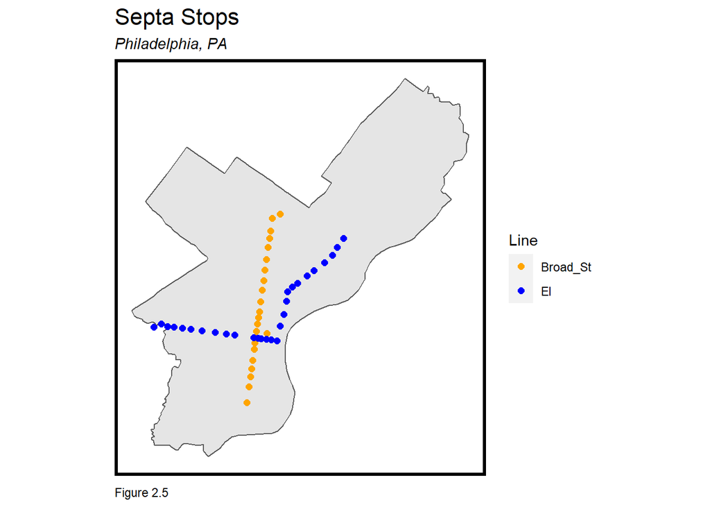

```r
ggplot() +
  geom_sf(data=st_union(tracts16)) +
  geom_sf(data=septaStops,
          aes(colour = Line),
          show.legend = "point", size= 2) +
  scale_colour_manual(values = c("orange","blue")) +
  labs(title="Septa Stops",
       subtitle="Philadelphia, PA",
       caption="Figure 2.5") +
  mapTheme()
```

### Relating SEPTA Stops and Tracts

Create buffers (in feet - note the CRS) around Septa stops - Both a buffer for each stop, and a union of the buffers… and bind these objects together

Let’s do this in pieces to understand this hefty code chunk.

We put them in the same data frame… why?

```r
stopBuffer <- st_buffer(septaStops, 2640)

stopUnion <- st_union(st_buffer(septaStops, 2640))

septaBuffers <-
  rbind(
     stopBuffer %>%
      mutate(Legend = "Buffer") %>%
      dplyr::select(Legend),
     stopUnion %>%
      st_sf() %>%
      mutate(Legend = "Unioned Buffer"))
```

Let’s examine both buffers by making a “[small multiples](https://www.juiceanalytics.com/writing/better-know-visualization-small-multiples)” plot. This type of plot shows multiple views of the same data or geographic area. We accomplish this by using the `facet_wrap()` {ggplot2} function on the *Legend* column.

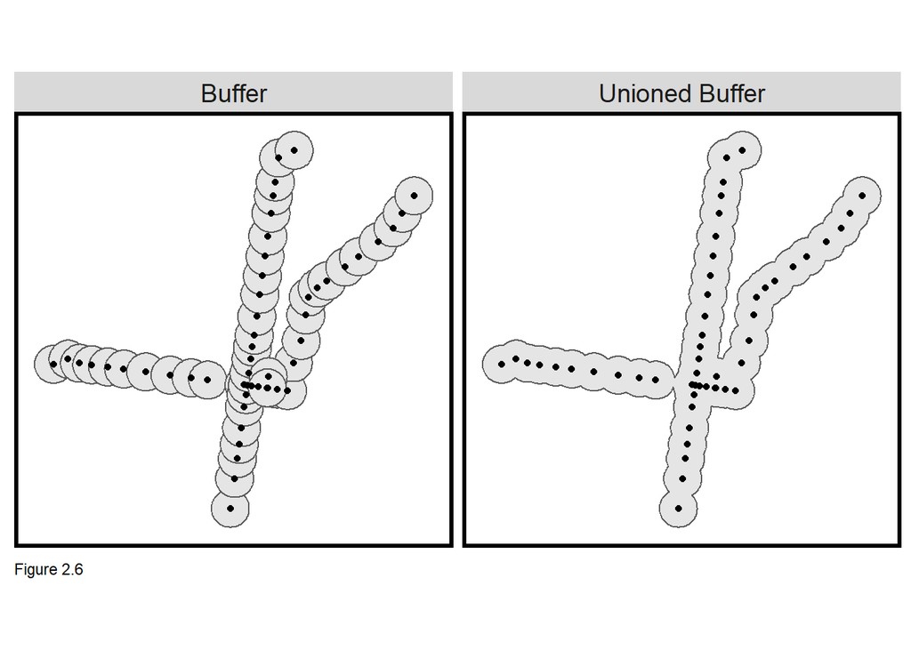

```r
ggplot() +
  geom_sf(data=septaBuffers) +
  geom_sf(data=septaStops, show.legend = "point") +
  facet_wrap(~Legend) +
  labs(caption = "Figure 2.6") +
  mapTheme()
```

### Using the `sf` Package for Spatial operations

Consult the text to understand the difference between these three types of joins and discuss which is likely appropriate for this analysis

Create an sf object with ONLY the unioned buffer from the `septaBuffers` spatial data frame.

```r
buffer <- filter(septaBuffers, Legend=="Unioned Buffer")
```

### Spatial Intersection of tracts and buffers

In this section, we deep dive a bit into three different ways to achieve a similar output. Namely, what we are accomplishing is to select the tracts from `tracts16` that intersect the buffer of transit stop in `buffer` . The three different ways to think about this operation are:

- The intersection returns only the areas where both `buffer` and `tracts16` polygons overlap. This is often referred to as “clipping”
- The intersection polygons are returns the full extend of any polygon in `tracts16` that touch (or intersect) the `buffer`. There is no clipping of the polygons
  - We will see three different ways to accomplish this particular outcome
- The intersection of polygons to centroids returns the full extent of any polygon in `tracts16` that has its center (called a centroid) within the `buffer`

The version of spatial intersection you chose will depend on the type of analysis you are doing. This concept is explained more deeply in the text book, lecture and labs.

Note: you will likely get a warning about “attribute variables are assumed…” don’t worry about it.

#### Spatial Clipping with `st_intersection()` on polygons

```r
clip <-
  st_intersection(buffer, tracts16) %>%
  dplyr::select(TotalPop) %>%
  mutate(Selection_Type = "Clip")
```

```
## Warning: attribute variables are assumed to be spatially constant throughout all
## geometries
```

#### Spatial intersection with `st_intersects()` on polygons

Simply, this type of spatial selection returns any polygon that overlaps or touches the buffer. We try to keep our code examples concise in this course, but here we show three different ways to achieve the same outcome.

1. `selection1` uses `tracts16[buffer,]` uses the least code, but is often confusing unless you know the {sf} package well. In this usage, the intersecting rows of `tracts16` are selected for by indexing on `buffer`. This method is very fast to compute, but hard to understand at first.
2. `selection2` is a longhand way to do the same. This uses `tracts16[st_intersects(tracts16, buffer) %>% lengths > 0, ]` to spell out all of the steps used in the first method. This can be read as: Select all rows of the rows from `tracts16` where `st_intersects()` returns a length of greater than zero. Important note that this uses `st_intersects()` and not `st_intersection()` as in the previous section. This approach is just as fast as approach #1, but a little easier to read.
3. `selection3` takes a different approach and uses `st_join()` with the join type of “st_intersects”. In this approach we need to follow the join with `filter(!is.na(Legend))` to remove the rows of `tracts16` where the polygons did not join. These are the polygons that did not intersect. This approach is the most readable and easiest to understand, but can be slower on large amounts of data.

```r
# Do a spatial selection to see which tracts touch the buffer

# approach #1: sub-setting a spatial object with a spatial object using the '[' brackets.
selection1 <-
  tracts16[buffer,] %>%
  dplyr::select(TotalPop) %>%
  mutate(Selection_Type = "Spatial Selection")

# approach #2: using `st_intersects` as a verbose way to do approach #1
selection2 <- tracts16[st_intersects(tracts16, buffer) %>% lengths > 0, ] %>%
  dplyr::select(TotalPop) %>%
  mutate(Selection_Type = "Spatial Selection")

# approach #3: use `st_join` to do a spatial join and remove the non-intersecting polygons
selection3 <- tracts16 %>%
  st_join(buffer, join = st_intersects) %>%
  filter(!is.na(Legend)) %>%
  dplyr::select(TotalPop) %>%
  mutate(Selection_Type = "Spatial Intersects")
```

#### Spatial intersection with with `st_centroid()` on polygon centroids

Finally, we are using centroids, or the point at the center of a polygon, to select whether a polygon from `tracts16` intersects the `buffer`. The steps here are:

1. convert tract polygons to centroids and to the spatial intersect to buffers using the `selection1` approach from above. The resulting geometry type is now a point and not a polygon
2. drop the geometry so that is becomes a regular non-spatial data frame
3. join the original `tracts16` data frame using the `GEOID` as the join field. Note that only the `GEOID` column is selected, however the polygon spatial features are also joined.
4. `st_sf()` is a function to turn it back to an {sf} spatial object
5. finally the `TotalPop` column is selected and a new field of `Selection_Type` is added

Note: you will get a warning about “st_centroid assumes attributes… don’t worry about it.

```r
selectCentroids <-
  st_centroid(tracts16)[buffer,] %>%
  st_drop_geometry() %>%
  left_join(., dplyr::select(tracts16, GEOID), by = "GEOID") %>%
  st_sf() %>%
  dplyr::select(TotalPop) %>%
  mutate(Selection_Type = "Select by Centroids")
```

```
## Warning in st_centroid.sf(tracts16): st_centroid assumes attributes are constant
## over geometries of x
```

Plotting the results of each method

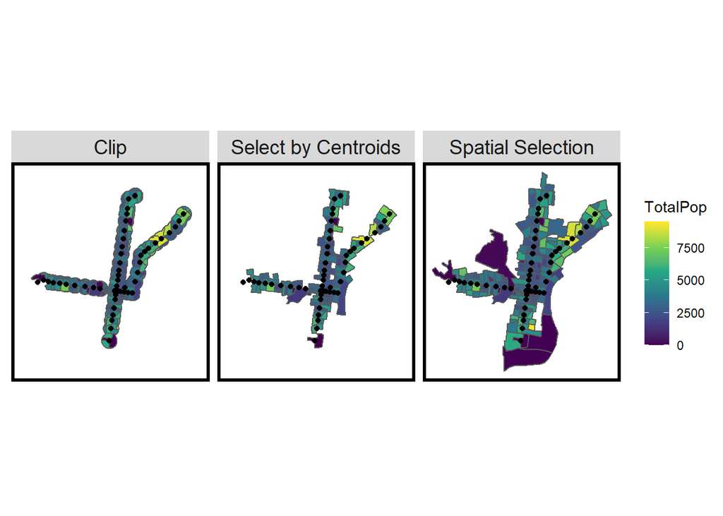

```r
intersections <- rbind(clip, selection1, selectCentroids)

ggplot() +
  geom_sf(data=intersections, aes(fill = TotalPop)) +
  geom_sf(data=septaStops, show.legend = "point") +
  scale_fill_viridis_c() +
  facet_wrap(~Selection_Type) +
  mapTheme()
```

## Bonus Exercise - Can you create a small multiple map of the three types of operations? (NOT GRADED)

Consult the text for some operations you can try. This is to be done in breakout groups

### Indicator Maps

```r
allTracts.group <-
  rbind(
    st_centroid(allTracts)[buffer,] %>%
      st_drop_geometry() %>%
      left_join(allTracts) %>%
      st_sf() %>%
      mutate(TOD = "TOD"),
    st_centroid(allTracts)[buffer, op = st_disjoint] %>%
      st_drop_geometry() %>%
      left_join(allTracts) %>%
      st_sf() %>%
      mutate(TOD = "Non-TOD")) %>%
  mutate(MedRent.inf = ifelse(year == "2009", MedRent * 1.14, MedRent))
```

[output not shown]

[output not shown]

Can you try to create the maps seen in the text? The solutions are contained in “map_exercise.R”

### TOD Indicator Tables

```r
allTracts.Summary <-
  st_drop_geometry(allTracts.group) %>%
  group_by(year, TOD) %>%
  summarize(Rent = mean(MedRent, na.rm = T),
            Population = mean(TotalPop, na.rm = T),
            Percent_White = mean(pctWhite, na.rm = T),
            Percent_Bach = mean(pctBachelors, na.rm = T),
            Percent_Poverty = mean(pctPoverty, na.rm = T))
kable(allTracts.Summary) %>%
  kable_styling() %>%
  footnote(general_title = "\n",
           general = "Table 2.2")
```

| year | TOD | Rent | Population | Percent_White | Percent_Bach | Percent_Poverty |
| --- | --- | --- | --- | --- | --- | --- |
| 2016 | Non-TOD | 792.6045 | 4034.629 | 0.4446612 | 0.0116239 | 0.2357755 |
| 2016 | TOD | 876.4904 | 3661.462 | 0.4780877 | 0.0290590 | 0.3120580 |
| 2020 | Non-TOD | 914.7802 | 3864.157 | 0.4197878 | 0.0102624 | 0.2049752 |
| 2020 | TOD | 1065.9107 | 3494.478 | 0.4680340 | 0.0328232 | 0.2591106 |

Table 2.2

Notice how we pipe the kable() command here

```r
allTracts.Summary %>%
  unite(year.TOD, year, TOD, sep = ": ", remove = T) %>%
  gather(Variable, Value, -year.TOD) %>%
  mutate(Value = round(Value, 2)) %>%
  spread(year.TOD, Value) %>%
  kable() %>%
  kable_styling() %>%
  footnote(general_title = "\n",
           general = "Table 2.3")
```

| Variable | 2016: Non-TOD | 2016: TOD | 2020: Non-TOD | 2020: TOD |
| --- | --- | --- | --- | --- |
| Percent_Bach | 0.01 | 0.03 | 0.01 | 0.03 |
| Percent_Poverty | 0.24 | 0.31 | 0.20 | 0.26 |
| Percent_White | 0.44 | 0.48 | 0.42 | 0.47 |
| Population | 4034.63 | 3661.46 | 3864.16 | 3494.48 |
| Rent | 792.60 | 876.49 | 914.78 | 1065.91 |

Table 2.3

### TOD Indicator Plots

Let’s create small multiple plots We use the “gather” command (look this one up please) To go from wide to long Why do we do this?? Notice we can “pipe” a ggplot call right into this operation!

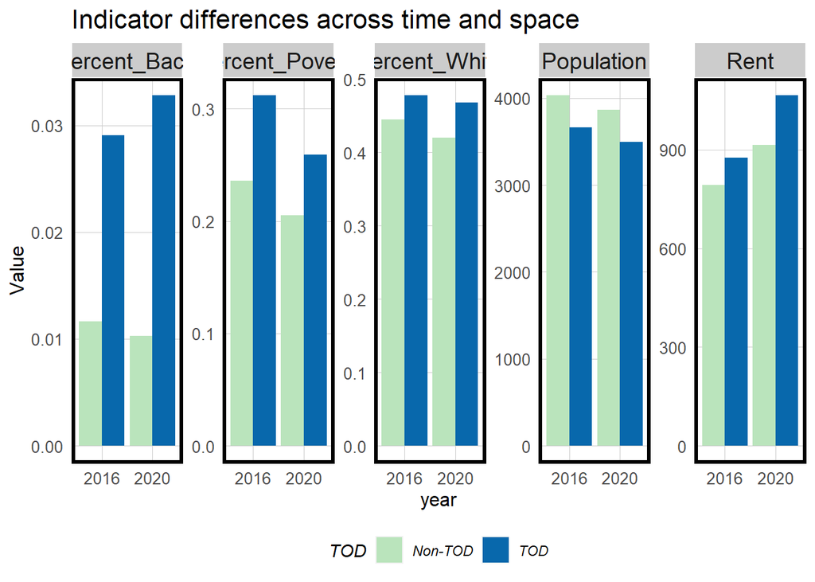

```r
allTracts.Summary %>%
  gather(Variable, Value, -year, -TOD) %>%
  ggplot(aes(year, Value, fill = TOD)) +
  geom_bar(stat = "identity", position = "dodge") +
  facet_wrap(~Variable, scales = "free", ncol=5) +
  scale_fill_manual(values = c("#bae4bc", "#0868ac")) +
  labs(title = "Indicator differences across time and space") +
  plotTheme() + theme(legend.position="bottom")
```

#### Examining three submarkets

```r
centerCity <-
  st_intersection(
    st_buffer(filter(septaStops, Line == "El"), 2640) %>% st_union(),
    st_buffer(filter(septaStops, Line == "Broad_St"), 2640) %>% st_union()) %>%
  st_sf() %>%
  mutate(Submarket = "Center City")

el <-
  st_buffer(filter(septaStops, Line == "El"), 2640) %>% st_union() %>%
  st_sf() %>%
  st_difference(centerCity) %>%
  mutate(Submarket = "El")
broad.st <-
  st_buffer(filter(septaStops, Line == "Broad_St"), 2640) %>% st_union() %>%
  st_sf() %>%
  st_difference(centerCity) %>%
  mutate(Submarket = "Broad Street")
threeMarkets <- rbind(el, broad.st, centerCity)
```

You can then bind these buffers to tracts and map them or make small multiple plots

```r
allTracts.threeMarkets <-
  st_join(st_centroid(allTracts), threeMarkets) %>%
  st_drop_geometry() %>%
  left_join(allTracts) %>%
  mutate(Submarket = replace_na(Submarket, "Non-TOD")) %>%
  st_sf()
```

[output not shown]

### Example of using `multipleRingBuffer()` function

There is a more comprehensive tutorial on the usage of this function (and the bugs you might encounter) in the Github folder!

```r
allTracts <- rbind(tracts20,tracts16)
septa_MRB <- multipleRingBuffer(st_union(septaStops), 47520, 2640)

allTracts.rings <-
  st_join(st_centroid(dplyr::select(allTracts, GEOID, year)),
          septa_MRB) %>%
  st_drop_geometry() %>%
  left_join(dplyr::select(allTracts, GEOID, MedRent, year),
            by=c("GEOID"="GEOID", "year"="year")) %>%
  st_sf() %>%
  mutate(distance = distance / 5280) #convert to miles
```

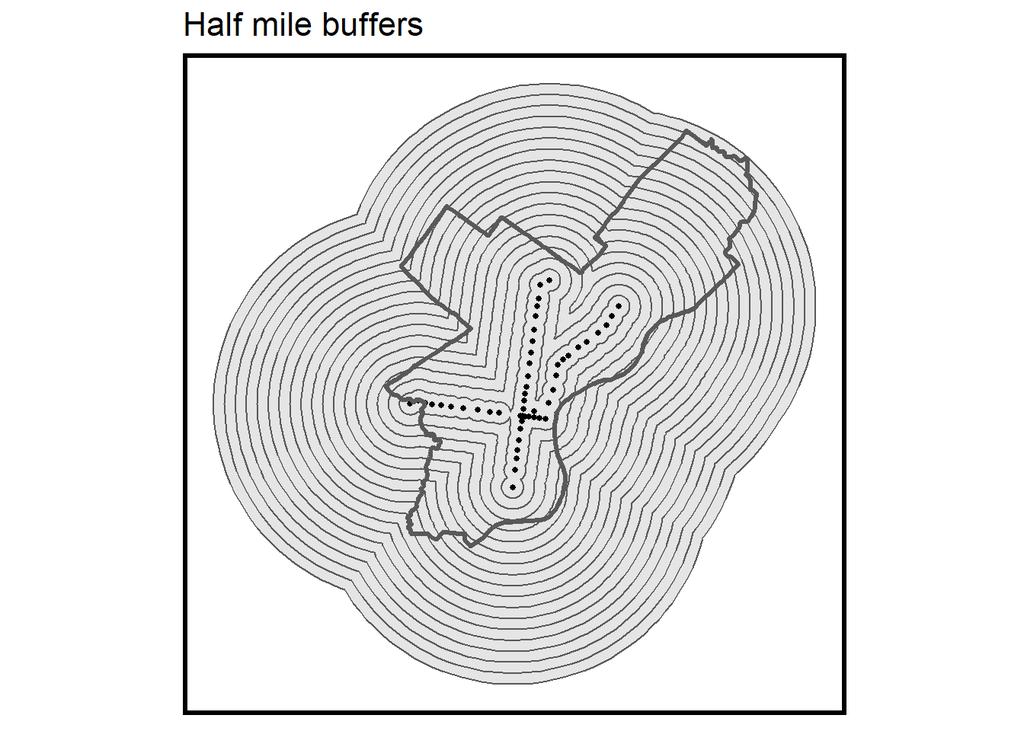

```r
  ggplot() +
    geom_sf(data=septa_MRB) +
    geom_sf(data=septaStops, size=1) +
    geom_sf(data=st_union(tracts20), fill=NA, size=1.2) +
    labs(title="Half mile buffers") +
    mapTheme()
```